# HARP2 analysis

Lina Kramer

1.03.2025

### 1. Data overview

- Exposure: simvastatin vs placebo.
- Survival outcome: 28-day and 90-day survival.
- Mediator: IL-6 on days 0 and 3.

### 2. Descriptives

#### 2.1. Table 1

```r
names(harp2_long) <- tolower(names(harp2_long))
# pivot wider to see missings and create table one
harp2_wide <- harp2_long %>% select(record.id, sex, age,  conc_log10, biomarker, day, randomized_group, apache, sofa, pfratio, class, time_mort28, death_d28, time_mort90, death_d90, time_discharge, icu_discharge) %>% filter(!is.na(randomized_group)) %>%
  unite("biomarker_day", biomarker, day, sep = "_") %>%
  pivot_wider(names_from = biomarker_day, values_from = conc_log10)
```

```r
tableone::CreateTableOne(harp2_wide, strata=c("randomized_group", "class"), vars=c('age', 'sex', 'apache', 'sofa', 'pfratio', "death_d28", "IL_6_0", "IL_6_3"), factorVars=c("death_d28", 'sex'), test=F) %>% print()
```

```
##                      Stratified by randomized_group:class
##                       Placebo:hyper-inflammatory Simvastatin:hyper-inflammatory
##   n                      96                         81
##   age (mean (SD))     59.97 (16.07)              60.33 (14.91)
##   sex = male (%)         56 (58.3)                  49 (60.5)
##   apache (mean (SD))  20.58 (6.12)               22.62 (6.36)
##   sofa (mean (SD))    10.69 (2.81)               11.23 (2.72)
##   pfratio (mean (SD)) 16.88 (6.52)               15.14 (6.95)
##   death_d28 = 1 (%)      44 (45.8)                  25 (30.9)
##   IL_6_0 (mean (SD))   2.58 (0.63)                2.59 (0.67)
##   IL_6_3 (mean (SD))   1.94 (0.56)                1.85 (0.52)
##                      Stratified by randomized_group:class
##                       Placebo:hypo-inflammatory Simvastatin:hypo-inflammatory
##   n                     169                       165
##   age (mean (SD))     51.57 (16.17)             49.45 (15.62)
##   sex = male (%)        103 (60.9)                 81 (49.1)
##   apache (mean (SD))  16.91 (5.96)              18.09 (6.83)
##   sofa (mean (SD))     7.86 (2.51)               7.32 (2.70)
##   pfratio (mean (SD)) 18.13 (7.74)              17.11 (7.38)
##   death_d28 = 1 (%)      29 (17.2)                 27 (16.4)
##   IL_6_0 (mean (SD))   1.93 (0.54)               1.94 (0.61)
##   IL_6_3 (mean (SD))   1.61 (0.50)               1.65 (0.54)
```

#### 2.2. Missingness

Of 540 patients, 28 have no IL-6 biomarker measures. They are not included in any of the analyses.

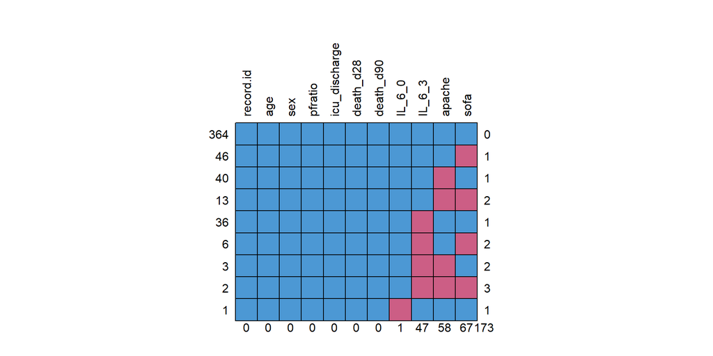

```r
missing_harp2 <- mice::md.pattern(harp2_wide[c("record.id", 'age', 'sex', 'apache', 'sofa', 'pfratio', 'icu_discharge', "death_d28", "death_d90", "IL_6_0", "IL_6_3")],
                                  rotate.names = TRUE, plot = TRUE)
```

#### 2.3. 28-day survival

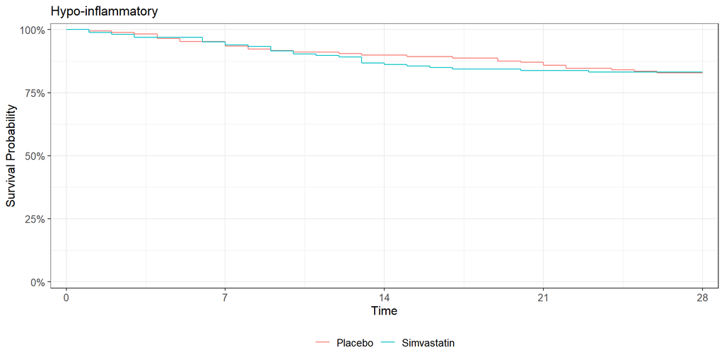

```r
# set the reference group
harp2_surv$randomized_group <- harp2_surv$randomized_group %>%  relevel(ref = "Placebo")
harp2_long$randomized_group <- harp2_long$randomized_group %>%  relevel(ref = "Placebo")

harp2_surv$class <- harp2_surv$class %>%  relevel(ref = "hypo-inflammatory")
harp2_long$class <- harp2_long$class %>%  relevel(ref = "hypo-inflammatory")
class(harp2_surv$death_d28) <- "integer"


## 28 days

# hypo-inflammatory
harp2_surv %>% filter(class =="hypo-inflammatory") %>%
  survfit2(Surv(time_mort28, death_d28) ~ randomized_group, data = .) %>%
  ggsurvfit()+
      scale_ggsurvfit(x_scales= list(breaks = c(0, 7, 14, 21, 28)))+
  ggtitle("Hypo-inflammatory")
```

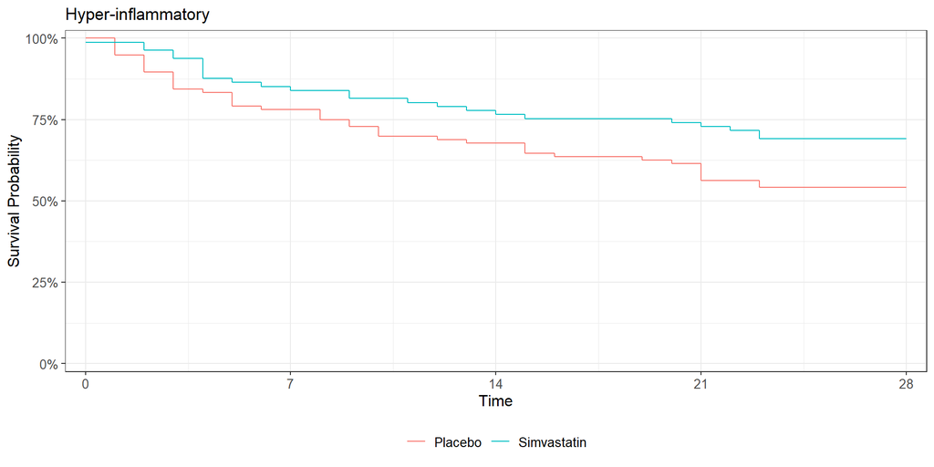

```r
# hyper-inflammatory
harp2_surv %>% filter(class == "hyper-inflammatory") %>%
  survfit2(Surv(time_mort28, death_d28) ~ randomized_group, data = .) %>%
  ggsurvfit()+
      scale_ggsurvfit(x_scales= list(breaks = c(0, 7, 14, 21, 28)))+
  ggtitle("Hyper-inflammatory")
```

#### 2.4. 90-day survival

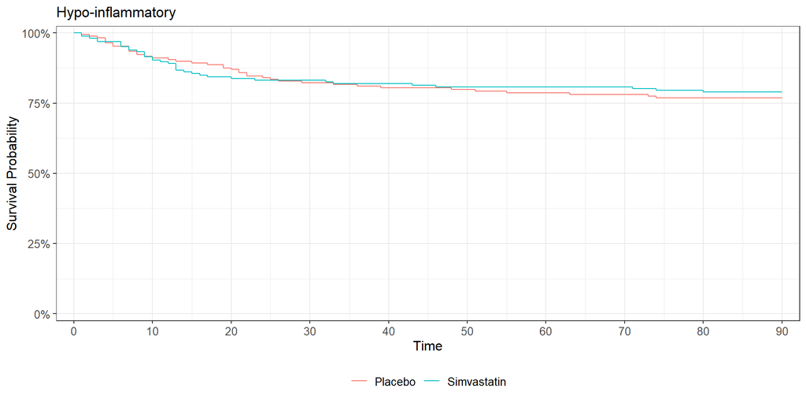

```r
class(harp2_surv$death_d90) <- "integer"

# hypo-inflammatory
harp2_surv %>% filter(class =="hypo-inflammatory") %>%
  survfit2(Surv(time_mort90, death_d90) ~ randomized_group, data = .) %>%
  ggsurvfit()+
      scale_ggsurvfit(x_scales= list(breaks = c(0, 10, 20, 30, 40, 50, 60, 70, 80, 90)))+
  ggtitle("Hypo-inflammatory")
```

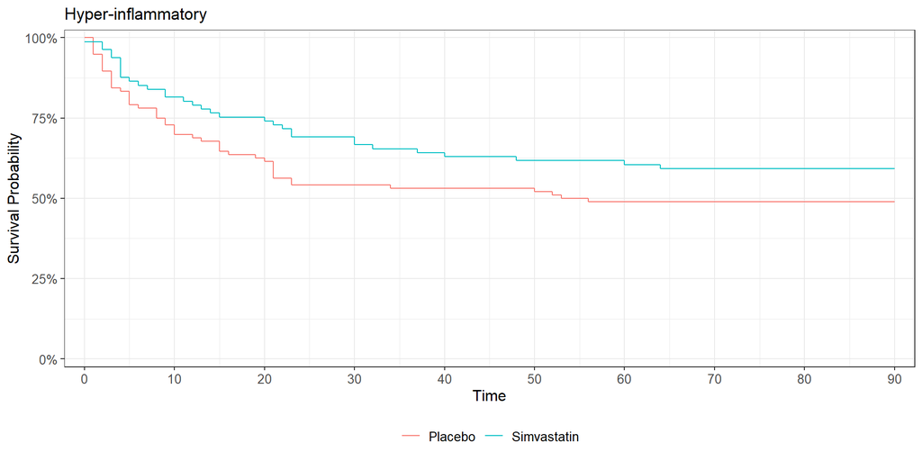

```r
# hyper-inflammatory
harp2_surv %>% filter(class == "hyper-inflammatory") %>%
  survfit2(Surv(time_mort90, death_d90) ~ randomized_group, data = .) %>%
  ggsurvfit()+
      scale_ggsurvfit(x_scales= list(breaks = c(0, 10, 20, 30, 40, 50, 60, 70, 80, 90)))+
  ggtitle("Hyper-inflammatory")
```

#### 2.5. IL-6 over time

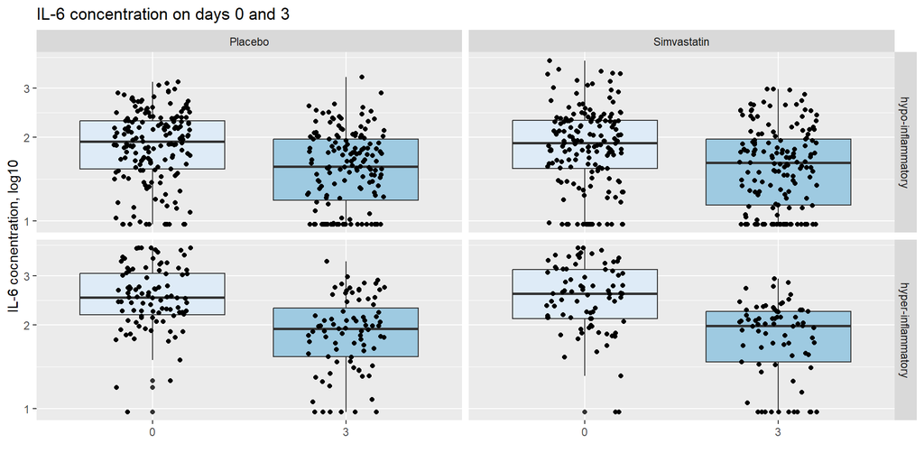

### 3. Models

#### 3.1. Linear-mixed model for IL-6 over time

##### 3.1.1. All patients

```r
# fit linear mixed mdoel
lmefit.harp2 <-lme(conc_log10~ day:randomized_group + day,
                   random = ~ day| record.id, data = harp2_long,
                   control = lmeControl(opt = "optim"),
                   na.action = na.omit)
summary(lmefit.harp2)
```

```
## Linear mixed-effects model fit by REML
##   Data: harp2_long
##        AIC      BIC    logLik
##   1692.078 1726.226 -839.0389
##
## Random effects:
##  Formula: ~day | record.id
##  Structure: General positive-definite, Log-Cholesky parametrization
##             StdDev    Corr
## (Intercept) 0.6329345 (Intr)
## day         0.1712806 -0.656
## Residual    0.2399541
##
## Fixed effects:  conc_log10 ~ day:randomized_group + day
##                                      Value  Std.Error  DF   t-value p-value
## (Intercept)                      2.1576459 0.02996575 510  72.00374  0.0000
## day                             -0.1448338 0.01171898 461 -12.35890  0.0000
## day:randomized_groupSimvastatin -0.0009719 0.01448550 461  -0.06709  0.9465
##  Correlation:
##                                 (Intr) day
## day                             -0.505
## day:randomized_groupSimvastatin  0.001 -0.603
##
## Standardized Within-Group Residuals:
##         Min          Q1         Med          Q3         Max
## -1.47495651 -0.30128358 -0.02112115  0.29115874  1.71825443
##
## Number of Observations: 974
## Number of Groups: 511
```

```
## Approximate 95% confidence intervals
##
##  Fixed effects:
##                                       lower          est.       upper
## (Intercept)                      2.09877443  2.1576459219  2.21651742
## day                             -0.16786300 -0.1448337552 -0.12180451
## day:randomized_groupSimvastatin -0.02943768 -0.0009718843  0.02749391
```

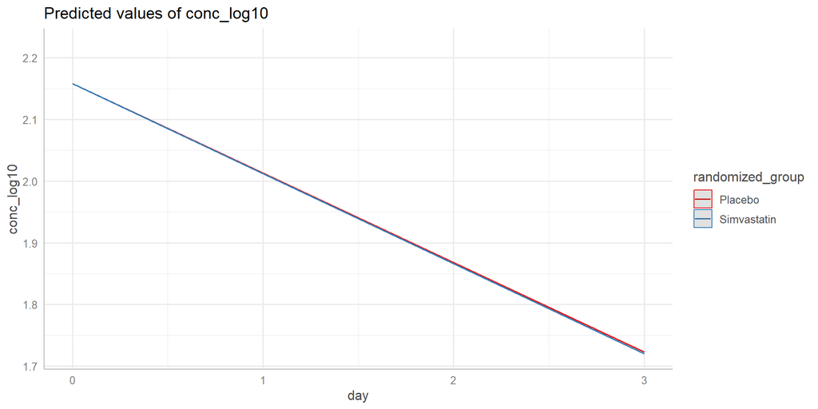

```r
library(sjPlot)
library(sjmisc)
theme_set(theme_sjplot())

plot_model(lmefit.harp2, type = "int", terms = c("randomized_group", "day"), show.values = TRUE )
```

##### 3.1.2. Hypo-inflammatory patients

```r
# hypo-inflammatory patients
lmefit.harp2_hypo <- harp2_long %>%
  filter(class == "hypo-inflammatory") %>%
  lme(conc_log10~ day:randomized_group + day,
      random = ~ day | record.id,
      data = .,
      control = lmeControl(opt = "optim"),
      na.action = na.omit)

summary(lmefit.harp2_hypo)
```

```
## Linear mixed-effects model fit by REML
##   Data: .
##        AIC      BIC    logLik
##   993.7966 1025.016 -489.8983
##
## Random effects:
##  Formula: ~day | record.id
##  Structure: General positive-definite, Log-Cholesky parametrization
##             StdDev    Corr
## (Intercept) 0.5331521 (Intr)
## day         0.1544744 -0.558
## Residual    0.2152448
##
## Fixed effects:  conc_log10 ~ day:randomized_group + day
##                                      Value  Std.Error  DF  t-value p-value
## (Intercept)                      1.9311269 0.03146053 333 61.38253  0.0000
## day                             -0.1086892 0.01345118 306 -8.08027  0.0000
## day:randomized_groupSimvastatin  0.0132996 0.01718965 306  0.77370  0.4397
##  Correlation:
##                                 (Intr) day
## day                             -0.434
## day:randomized_groupSimvastatin  0.000 -0.635
##
## Standardized Within-Group Residuals:
##         Min          Q1         Med          Q3         Max
## -1.27916502 -0.33428184 -0.01429082  0.29682586  1.66541503
##
## Number of Observations: 642
## Number of Groups: 334
```

```r
intervals(lmefit.harp2_hypo, which = "fixed")
```

```
## Approximate 95% confidence intervals
##
##  Fixed effects:
##                                       lower        est.       upper
## (Intercept)                      1.86924048  1.93112691  1.99301334
## day                             -0.13515767 -0.10868915 -0.08222063
## day:randomized_groupSimvastatin -0.02052526  0.01329961  0.04712448
```

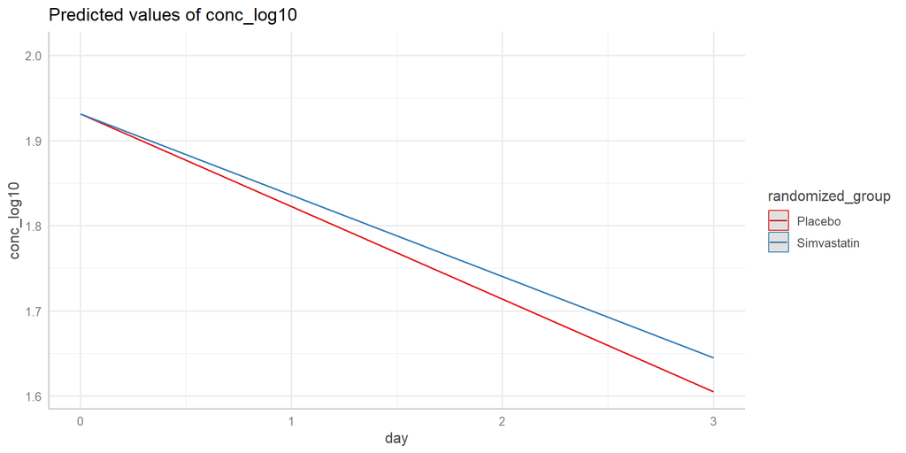

```r
plot_model(lmefit.harp2_hypo, type = "int", terms = c("day", "randomized_group"), show.ci = FALSE)
```

##### 3.1.3. Hyper-inflammatory patients

```r
# hyper-inflammatory patients
lmefit.harp2_hyper <- harp2_long %>%
  filter(class == "hyper-inflammatory") %>%
  lme(conc_log10~  day:randomized_group + day,
      random = ~ day | record.id,
      data = .,
      control = lmeControl(opt = "optim"),
      na.action = na.omit)

summary(lmefit.harp2_hyper)
```

```
## Linear mixed-effects model fit by REML
##   Data: .
##        AIC     BIC    logLik
##   597.5436 624.116 -291.7718
##
## Random effects:
##  Formula: ~day | record.id
##  Structure: General positive-definite, Log-Cholesky parametrization
##             StdDev    Corr
## (Intercept) 0.6033274 (Intr)
## day         0.1852714 -0.65
## Residual    0.2398584
##
## Fixed effects:  conc_log10 ~ day:randomized_group + day
##                                      Value  Std.Error  DF   t-value p-value
## (Intercept)                      2.5863065 0.04891606 176  52.87233  0.0000
## day                             -0.2141738 0.02102020 153 -10.18895  0.0000
## day:randomized_groupSimvastatin -0.0289217 0.02641800 153  -1.09477  0.2753
##  Correlation:
##                                 (Intr) day
## day                             -0.510
## day:randomized_groupSimvastatin  0.002 -0.590
##
## Standardized Within-Group Residuals:
##         Min          Q1         Med          Q3         Max
## -1.22265205 -0.29689029 -0.01228725  0.33446652  1.01074828
##
## Number of Observations: 332
## Number of Groups: 177
```

```r
# hyper-inflammatory patients # using only il6to day 3
#lmefit.harp2_hyper_2 <- harp2_long %>%
 # filter(class == "hyper-inflammatory" & day <7) %>%
#  lme(conc_log10~  day*randomized_group,
#      random = ~ day | record.id,
#      data = .,
#      control = lmeControl(opt = "optim"),
#      na.action = na.omit)

#summary(lmefit.harp2_hyper_2)
```

```r
intervals(lmefit.harp2_hyper, which = "fixed")
```

```
## Approximate 95% confidence intervals
##
##  Fixed effects:
##                                       lower        est.      upper
## (Intercept)                      2.48976896  2.58630649  2.6828440
## day                             -0.25570107 -0.21417377 -0.1726465
## day:randomized_groupSimvastatin -0.08111288 -0.02892174  0.0232694
```

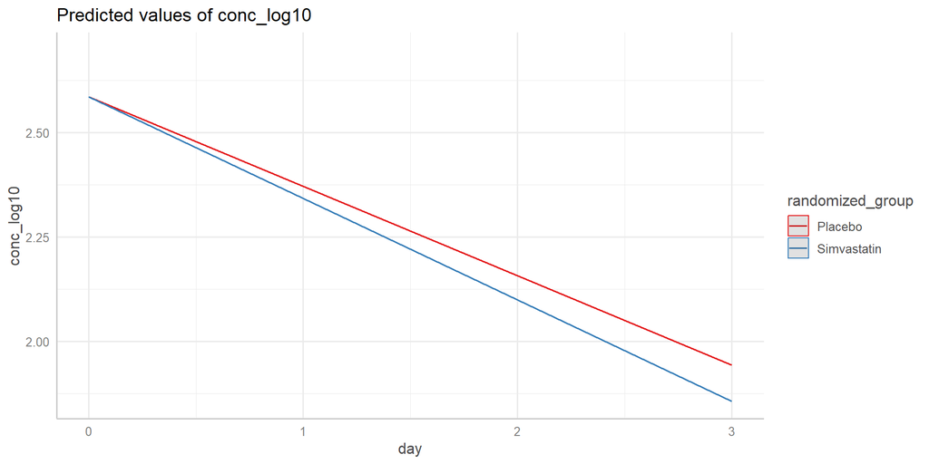

```r
plot_model(lmefit.harp2_hyper, type = "int", terms = c("randomized_group", "day"), show.values = TRUE)
```

```r
# save the interaction estimates
a_res <- get_int(lmefit.harp2, "randomized_groupSimvastatin")
a_res_o <- get_int(lmefit.harp2_hypo, "randomized_groupSimvastatin")
a_res_y <- get_int(lmefit.harp2_hyper, "randomized_groupSimvastatin")

a_res <- cbind(rbind(a_res, a_res_o, a_res_y),
               class = c("All", "Hypo-inflammatory", "Hyper-inflammatory"))

saveRDS(a_res, "harp2_beta_est.rds")
```

#### 3.2. Cox proportional hazards models

For 28-day and 90-day survival.

##### 3.2.1. 28-day survival: All patients

```r
# Fit cox proportional hazard model
coxfit.harp2_28 <- coxph(Surv(time_mort28, death_d28) ~ randomized_group, data = harp2_surv, x = TRUE)

summary(coxfit.harp2_28)
```

```
## Call:
## coxph(formula = Surv(time_mort28, death_d28) ~ randomized_group,
##     data = harp2_surv, x = TRUE)
##
##   n= 512, number of events= 126
##
##                                coef exp(coef) se(coef)      z Pr(>|z|)
## randomized_groupSimvastatin -0.2829    0.7536   0.1805 -1.567    0.117
##
##                             exp(coef) exp(-coef) lower .95 upper .95
## randomized_groupSimvastatin    0.7536      1.327    0.5291     1.073
##
## Concordance= 0.535  (se = 0.022 )
## Likelihood ratio test= 2.49  on 1 df,   p=0.1
## Wald test            = 2.46  on 1 df,   p=0.1
## Score (logrank) test = 2.47  on 1 df,   p=0.1
```

```r
confint(coxfit.harp2_28) %>% exp() %>% round(3)
```

```
##                             2.5 % 97.5 %
## randomized_groupSimvastatin 0.529  1.073
```

##### 3.2.2. 28-day survival: hypo-inflammatory patients

```r
# hypo-inflammatory
harp2_surv_hypo <- harp2_surv %>%
  filter(class == "hypo-inflammatory")

coxfit.harp2_hypo_28 <- coxph(Surv(time_mort28, death_d28)~ randomized_group, data = harp2_surv_hypo, x=TRUE)

summary(coxfit.harp2_hypo_28)
```

```
## Call:
## coxph(formula = Surv(time_mort28, death_d28) ~ randomized_group,
##     data = harp2_surv_hypo, x = TRUE)
##
##   n= 335, number of events= 57
##
##                                 coef exp(coef) se(coef)      z Pr(>|z|)
## randomized_groupSimvastatin -0.00462   0.99539  0.26496 -0.017    0.986
##
##                             exp(coef) exp(-coef) lower .95 upper .95
## randomized_groupSimvastatin    0.9954      1.005    0.5922     1.673
##
## Concordance= 0.499  (se = 0.033 )
## Likelihood ratio test= 0  on 1 df,   p=1
## Wald test            = 0  on 1 df,   p=1
## Score (logrank) test = 0  on 1 df,   p=1
```

##### 3.2.3. 28-day survival: hyper-inflammatory patients

```r
# hyper-inflammatory
harp2_surv_hyper <-  harp2_surv %>%
  filter(class == "hyper-inflammatory")

coxfit.harp2_hyper_28 <- coxph(Surv(time_mort28, death_d28)~ randomized_group, data =  harp2_surv_hyper, x=TRUE)

summary(coxfit.harp2_hyper_28)
```

```
## Call:
## coxph(formula = Surv(time_mort28, death_d28) ~ randomized_group,
##     data = harp2_surv_hyper, x = TRUE)
##
##   n= 177, number of events= 69
##
##                                coef exp(coef) se(coef)      z Pr(>|z|)
## randomized_groupSimvastatin -0.5091    0.6010   0.2506 -2.032   0.0422 *
## ---
## Signif. codes:  0 '***' 0.001 '**' 0.01 '*' 0.05 '.' 0.1 ' ' 1
##
##                             exp(coef) exp(-coef) lower .95 upper .95
## randomized_groupSimvastatin     0.601      1.664    0.3678    0.9822
##
## Concordance= 0.564  (se = 0.03 )
## Likelihood ratio test= 4.28  on 1 df,   p=0.04
## Wald test            = 4.13  on 1 df,   p=0.04
## Score (logrank) test = 4.22  on 1 df,   p=0.04
```

##### 3.2.4. 90-day survival: All patients

```r
# Fit cox proportional hazard model
coxfit.harp2_90 <- coxph(Surv(time_mort90, death_d90) ~ randomized_group, data = harp2_surv, x = TRUE)

summary(coxfit.harp2_90)
```

```
## Call:
## coxph(formula = Surv(time_mort90, death_d90) ~ randomized_group,
##     data = harp2_surv, x = TRUE)
##
##   n= 512, number of events= 156
##
##                                coef exp(coef) se(coef)      z Pr(>|z|)
## randomized_groupSimvastatin -0.2288    0.7955   0.1615 -1.417    0.157
##
##                             exp(coef) exp(-coef) lower .95 upper .95
## randomized_groupSimvastatin    0.7955      1.257    0.5797     1.092
##
## Concordance= 0.529  (se = 0.02 )
## Likelihood ratio test= 2.02  on 1 df,   p=0.2
## Wald test            = 2.01  on 1 df,   p=0.2
## Score (logrank) test = 2.02  on 1 df,   p=0.2
```

```r
confint(coxfit.harp2_90) %>% exp() %>% round(3)
```

```
##                             2.5 % 97.5 %
## randomized_groupSimvastatin  0.58  1.092
```

##### 3.2.5. 90-day survival: hypo-inflammatory

```r
# hypo-inflammatory
coxfit.harp2_hypo_90 <- coxph(Surv(time_mort90, death_d90)~ randomized_group, data = harp2_surv_hypo, x=TRUE)

summary(coxfit.harp2_hypo_90)
```

```
## Call:
## coxph(formula = Surv(time_mort90, death_d90) ~ randomized_group,
##     data = harp2_surv_hypo, x = TRUE)
##
##   n= 335, number of events= 74
##
##                                 coef exp(coef) se(coef)      z Pr(>|z|)
## randomized_groupSimvastatin -0.08439   0.91907  0.23285 -0.362    0.717
##
##                             exp(coef) exp(-coef) lower .95 upper .95
## randomized_groupSimvastatin    0.9191      1.088    0.5823     1.451
##
## Concordance= 0.508  (se = 0.029 )
## Likelihood ratio test= 0.13  on 1 df,   p=0.7
## Wald test            = 0.13  on 1 df,   p=0.7
## Score (logrank) test = 0.13  on 1 df,   p=0.7
```

##### 3.2.6. 90-day survival: hyper-inflammatory

```r
# hyper-inflammatory
coxfit.harp2_hyper_90<-  coxph(Surv(time_mort90, death_d90)~ randomized_group, data = harp2_surv_hyper, x=TRUE)

summary(coxfit.harp2_hyper_90)
```

```
## Call:
## coxph(formula = Surv(time_mort90, death_d90) ~ randomized_group,
##     data = harp2_surv_hyper, x = TRUE)
##
##   n= 177, number of events= 82
##
##                                coef exp(coef) se(coef)      z Pr(>|z|)
## randomized_groupSimvastatin -0.3527    0.7028   0.2253 -1.566    0.117
##
##                             exp(coef) exp(-coef) lower .95 upper .95
## randomized_groupSimvastatin    0.7028      1.423    0.4519     1.093
##
## Concordance= 0.549  (se = 0.028 )
## Likelihood ratio test= 2.5  on 1 df,   p=0.1
## Wald test            = 2.45  on 1 df,   p=0.1
## Score (logrank) test = 2.48  on 1 df,   p=0.1
```

#### 3.3. Joint models

Using 28- and 90-day survival as endpoints.

Fit joint models for:

- Survival to day 28 of 1) All patients, 2) hypo-, & 3) hyper-inflammatory.
- Survival to day 90: 4) All patients, 5) hypo-, & 6) hyper-inflammatory.

```r
################################################################################
### Joint models ###############################################################
################################################################################

require(JMbayes2)
set.seed(15)

### 28-day survival ############################################################

# All patients -----------------------------------------------------------------

## fit joint model
jointfit.harp2_28<- JMbayes2::jm(coxfit.harp2_28,
                                   lmefit.harp2,
                                   time_var = "day", n_iter = 60000L,
                                   n_burnin = 5000L, n_chains = 2L,
                                   n_thin = 5L, cores= 2)

saveRDS(jointfit.harp2_28, "jointfit_harp2_28.rds")

# hypo-inflammatory patients ---------------------------------------------------

## fit joint model
jointfit.harp2_hypo_28<- JMbayes2::jm(coxfit.harp2_hypo_28,
                                        lmefit.harp2_hypo,
                                        time_var = "day",  n_iter = 60000L,
                                   n_burnin = 5000L, n_chains = 2L,
                                   n_thin = 5L, cores= 2)


saveRDS(jointfit.harp2_hypo_28, "jointfit_harp2_hypo_28.rds")

# hyper-inflammatory patients --------------------------------------------------

## fit joint model
jointfit.harp2_hyper_28<- JMbayes2::jm(coxfit.harp2_hyper_28,
                                         lmefit.harp2_hyper,
                                         time_var = "day",  n_iter = 60000L,
                                   n_burnin = 5000L, n_chains = 2L,
                                   n_thin = 5L, cores= 2)

saveRDS(jointfit.harp2_hyper_28, "jointfit_harp2_hyper_28.rds")

### 90-day survival ############################################################

# All patients -----------------------------------------------------------------

## fit joint model
jointfit.harp2_90<- JMbayes2::jm(coxfit.harp2_90,
                                   lmefit.harp2,
                                   time_var = "day", n_iter = 60000L,
                                   n_burnin = 5000L, n_chains = 2L,
                                   n_thin = 5L, cores= 2)


saveRDS(jointfit.harp2_90, "jointfit_harp2_90.rds")

# hypo-inflammatory patients ---------------------------------------------------

# hypo-inflammatory patients ---------------------------------------------------

## fit joint model
jointfit.harp2_hypo_90<- JMbayes2::jm(coxfit.harp2_hypo_90,
                                        lmefit.harp2_hypo,
                                        time_var = "day", n_iter = 60000L,
                                   n_burnin = 5000L, n_chains = 2L,
                                   n_thin = 5L, cores= 2)


saveRDS(jointfit.harp2_hypo_90, "jointfit_harp2_hypo_90.rds")

# hyper-inflammatory patients --------------------------------------------------

## fit joint model
jointfit.harp2_hyper_90<- JMbayes2::jm(coxfit.harp2_hyper_90,
                                         lmefit.harp2_hyper,
                                         time_var = "day", n_iter = 60000L,
                                   n_burnin = 5000L, n_chains = 2L,
                                   n_thin = 5L, cores= 2)


saveRDS(jointfit.harp2_hyper_90, "jointfit_harp2_hyper_90.rds")
```

##### 3.3.1. 28-day endpoint: All patients

```
##
## Call:
## JMbayes2::jm(Surv_object = coxfit.harp2_28, Mixed_objects = lmefit.harp2,
##     time_var = "day", n_iter = 60000L, n_burnin = 5000L, n_chains = 2L,
##     n_thin = 5L, cores = 2)
##
## Data Descriptives:
## Number of Groups: 512        Number of events: 126 (24.6%)
## Number of Observations:
##   conc_log10: 974
##
##                  DIC     WAIC      LPML
## marginal    3370.072 5470.073 -4872.031
## conditional 2155.978 2306.107 -1620.585
##
## Random-effects covariance matrix:
##
##        StdDev   Corr
## (Intr) 0.5455 (Intr)
## day    0.1058 -0.5803
##
## Survival Outcome:
##                                Mean  StDev    2.5%  97.5%      P   Rhat
## randomized_groupSimvastatin -0.2448 0.2646 -0.7525 0.2785 0.3570 0.9999
## value(conc_log10)            0.6576 0.5643 -0.0390 1.7171 0.1074 1.1300
##
## Longitudinal Outcome: conc_log10 (family = gaussian, link = identity)
##                Mean  StDev    2.5%   97.5%     P   Rhat
## (Intercept)  2.1580 0.0292  2.1005  2.2152 0.000 1.0005
## day         -0.1428 0.0116 -0.1657 -0.1202 0.000 1.0019
## d:_S        -0.0044 0.0142 -0.0320  0.0242 0.744 1.0009
## sigma        0.3592 0.0710  0.1733  0.4373 0.000 1.3016
##
## MCMC summary:
## chains: 2
## iterations per chain: 60000
## burn-in per chain: 5000
## thinning: 5
## time: 5.5 min
```

##### 3.3.2. 28-day endpoint: hypo-inflammatory

```
##
## Call:
## JMbayes2::jm(Surv_object = coxfit.harp2_hypo_28, Mixed_objects = lmefit.harp2_hypo,
##     time_var = "day", n_iter = 60000L, n_burnin = 5000L, n_chains = 2L,
##     n_thin = 5L, cores = 2)
##
## Data Descriptives:
## Number of Groups: 334        Number of events: 56 (16.8%)
## Number of Observations:
##   conc_log10: 642
##
##                  DIC     WAIC       LPML
## marginal    1640.616 1960.376 -1246.4225
## conditional 1039.204 1068.012  -850.3171
##
## Random-effects covariance matrix:
##
##        StdDev   Corr
## (Intr) 0.4453 (Intr)
## day    0.0819 -0.4374
##
## Survival Outcome:
##                                Mean  StDev    2.5%  97.5%      P   Rhat
## randomized_groupSimvastatin -0.0550 0.3670 -0.7624 0.6630 0.8798 1.0011
## value(conc_log10)            0.3704 0.4235 -0.4065 1.2782 0.3341 1.0259
##
## Longitudinal Outcome: conc_log10 (family = gaussian, link = identity)
##                Mean  StDev    2.5%   97.5%      P   Rhat
## (Intercept)  1.9308 0.0312  1.8697  1.9915 0.0000 1.0000
## day         -0.1063 0.0144 -0.1348 -0.0775 0.0000 1.0006
## d:_S         0.0090 0.0181 -0.0273  0.0450 0.6164 1.0027
## sigma        0.3478 0.0489  0.1963  0.4071 0.0000 1.0040
##
## MCMC summary:
## chains: 2
## iterations per chain: 60000
## burn-in per chain: 5000
## thinning: 5
## time: 4.2 min
```

##### 3.3.3. 28-day endpoint: hyper-inflammatory

```
##
## Call:
## JMbayes2::jm(Surv_object = coxfit.harp2_hyper_28, Mixed_objects = lmefit.harp2_hyper,
##     time_var = "day", n_iter = 60000L, n_burnin = 5000L, n_chains = 2L,
##     n_thin = 5L, cores = 2)
##
## Data Descriptives:
## Number of Groups: 177        Number of events: 69 (39%)
## Number of Observations:
##   conc_log10: 332
##
##                  DIC     WAIC       LPML
## marginal    1418.762 1729.947 -1322.0419
## conditional 1045.917 1065.774  -702.0319
##
## Random-effects covariance matrix:
##
##        StdDev   Corr
## (Intr) 0.5398 (Intr)
## day    0.1448 -0.5841
##
## Survival Outcome:
##                                Mean  StDev    2.5%  97.5%      P   Rhat
## randomized_groupSimvastatin -0.4415 0.3533 -1.1306 0.2412 0.2105 1.0033
## value(conc_log10)            0.3431 0.3064 -0.0267 1.1407 0.0813 1.1543
##
## Longitudinal Outcome: conc_log10 (family = gaussian, link = identity)
##                Mean  StDev    2.5%   97.5%      P   Rhat
## (Intercept)  2.5854 0.0477  2.4915  2.6792 0.0000 1.0009
## day         -0.2123 0.0210 -0.2532 -0.1709 0.0000 1.0028
## d:_S        -0.0286 0.0265 -0.0805  0.0237 0.2775 1.0011
## sigma        0.3261 0.0987  0.1141  0.4611 0.0000 1.0145
##
## MCMC summary:
## chains: 2
## iterations per chain: 60000
## burn-in per chain: 5000
## thinning: 5
## time: 2.7 min
```

##### 3.3.4. 90-day endpoint: All patients

```
##
## Call:
## JMbayes2::jm(Surv_object = coxfit.harp2_90, Mixed_objects = lmefit.harp2,
##     time_var = "day", n_iter = 60000L, n_burnin = 5000L, n_chains = 2L,
##     n_thin = 5L, cores = 2)
##
## Data Descriptives:
## Number of Groups: 512        Number of events: 156 (30.5%)
## Number of Observations:
##   conc_log10: 974
##
##                  DIC     WAIC      LPML
## marginal    3766.224 4459.563 -3057.364
## conditional 2950.150 2917.354 -1958.385
##
## Random-effects covariance matrix:
##
##        StdDev   Corr
## (Intr) 0.5978 (Intr)
## day    0.1441 -0.6442
##
## Survival Outcome:
##                                Mean  StDev    2.5%  97.5%      P   Rhat
## randomized_groupSimvastatin -0.2316 0.2122 -0.6506 0.1786 0.2817 1.0000
## value(conc_log10)            0.0627 0.0721 -0.0295 0.2413 0.1905 1.0069
##
## Longitudinal Outcome: conc_log10 (family = gaussian, link = identity)
##                Mean  StDev    2.5%   97.5%      P   Rhat
## (Intercept)  2.1574 0.0297  2.0990  2.2154 0.0000 1.0002
## day         -0.1449 0.0117 -0.1680 -0.1220 0.0000 1.0002
## d:_S        -0.0006 0.0145 -0.0292  0.0281 0.9695 1.0001
## sigma        0.2959 0.0822  0.1058  0.4061 0.0000 1.0599
##
## MCMC summary:
## chains: 2
## iterations per chain: 60000
## burn-in per chain: 5000
## thinning: 5
## time: 5.9 min
```

##### 3.3.5. 90-day endpoint: hypo-inflammatory

```
##
## Call:
## JMbayes2::jm(Surv_object = coxfit.harp2_hypo_90, Mixed_objects = lmefit.harp2_hypo,
##     time_var = "day", n_iter = 60000L, n_burnin = 5000L, n_chains = 2L,
##     n_thin = 5L, cores = 2)
##
## Data Descriptives:
## Number of Groups: 334        Number of events: 73 (21.9%)
## Number of Observations:
##   conc_log10: 642
##
##                  DIC     WAIC      LPML
## marginal    1892.232 2204.232 -1592.754
## conditional 1336.350 1346.826 -1013.923
##
## Random-effects covariance matrix:
##
##        StdDev   Corr
## (Intr) 0.4493 (Intr)
## day    0.0821 -0.4676
##
## Survival Outcome:
##                                Mean  StDev    2.5%  97.5%      P   Rhat
## randomized_groupSimvastatin -0.1371 0.3201 -0.7552 0.4846 0.6785 1.0003
## value(conc_log10)            0.1495 0.1934 -0.1769 0.6145 0.3817 1.0194
##
## Longitudinal Outcome: conc_log10 (family = gaussian, link = identity)
##                Mean  StDev    2.5%   97.5%      P   Rhat
## (Intercept)  1.9309 0.0312  1.8694  1.9922 0.0000 0.9999
## day         -0.1070 0.0136 -0.1336 -0.0802 0.0000 1.0002
## d:_S         0.0100 0.0171 -0.0232  0.0441 0.5654 1.0006
## sigma        0.3482 0.0454  0.2202  0.4047 0.0000 1.1667
##
## MCMC summary:
## chains: 2
## iterations per chain: 60000
## burn-in per chain: 5000
## thinning: 5
## time: 3.5 min
```

##### 3.3.6. 90-day endpoint: hyper-inflammatory

```
##
## Call:
## JMbayes2::jm(Surv_object = coxfit.harp2_hyper_90, Mixed_objects = lmefit.harp2_hyper,
##     time_var = "day", n_iter = 60000L, n_burnin = 5000L, n_chains = 2L,
##     n_thin = 5L, cores = 2)
##
## Data Descriptives:
## Number of Groups: 177        Number of events: 82 (46.3%)
## Number of Observations:
##   conc_log10: 332
##
##                  DIC     WAIC       LPML
## marginal    1569.096 2021.727 -2450.7303
## conditional 1230.478 1238.808  -794.8923
##
## Random-effects covariance matrix:
##
##        StdDev   Corr
## (Intr) 0.5656 (Intr)
## day    0.1636 -0.6000
##
## Survival Outcome:
##                                Mean  StDev    2.5%  97.5%      P   Rhat
## randomized_groupSimvastatin -0.3120 0.3006 -0.9020 0.2643 0.3070 1.0000
## value(conc_log10)            0.1364 0.0929  0.0091 0.3763 0.0367 1.0731
##
## Longitudinal Outcome: conc_log10 (family = gaussian, link = identity)
##                Mean  StDev    2.5%   97.5%     P   Rhat
## (Intercept)  2.5862 0.0481  2.4909  2.6806 0.000 1.0010
## day         -0.2153 0.0211 -0.2562 -0.1737 0.000 1.0047
## d:_S        -0.0248 0.0271 -0.0782  0.0284 0.359 1.0028
## sigma        0.2849 0.0950  0.1026  0.4391 0.000 1.0001
##
## MCMC summary:
## chains: 2
## iterations per chain: 60000
## burn-in per chain: 5000
## thinning: 5
## time: 2.5 min
```

### 4. Results

#### 4.1. Indirect, direct, and total effects

Of randomized_groupSimvastatin through IL6 on mortality for:

- 1. All patients; 28-day endpoint.
- 2. Hypo-inflammatory patients; 28-day endpoint.
- 3. Hyper-inflammatory patients; 28-day endpoint.
- 4. All patients; 90-day endpoint.
- 5. Hypo-inflammatory patients; 90-day endpoint.
- 6. Hyper-inflammatory patients; 90-day endpoint.

```r
# 1
res28 <- get_effects(jointfit.harp2_28, coxfit.harp2_28,
                     "randomized_groupSimvastatin") %>%
  cbind(endpoint ="28-day endpoint",
        class = "All")

res28
```

```
##           effect          est    CI_lower   CI_upper        endpoint class
## 1         direct -0.244794947 -0.75249461 0.27849630 28-day endpoint   All
## 2       indirect -0.002873548 -0.03412646 0.01570969 28-day endpoint   All
## 3 total (Cox-PH) -0.282876347 -0.63658733 0.07083464 28-day endpoint   All
## 4     total (JM) -0.247668496 -0.75097926 0.26254446 28-day endpoint   All
```

```r
# 2
res28_o <- get_effects(jointfit.harp2_hypo_28, coxfit.harp2_hypo_28,
                     "randomized_groupSimvastatin") %>%
  cbind(endpoint ="28-day endpoint",
        class = "Hypo-inflammatory")
res28_o
```

```
##           effect          est    CI_lower   CI_upper        endpoint
## 1         direct -0.055025323 -0.76239499 0.66303148 28-day endpoint
## 2       indirect  0.003326027 -0.02177382 0.02409788 28-day endpoint
## 3 total (Cox-PH) -0.004620092 -0.52392938 0.51468920 28-day endpoint
## 4     total (JM) -0.051699296 -0.75303637 0.65897434 28-day endpoint
##               class
## 1 Hypo-inflammatory
## 2 Hypo-inflammatory
## 3 Hypo-inflammatory
## 4 Hypo-inflammatory
```

```r
# 3
res28_y <- get_effects(jointfit.harp2_hyper_28, coxfit.harp2_hyper_28,
                     "randomized_groupSimvastatin") %>%
  cbind(endpoint ="28-day endpoint",
        class = "Hyper-inflammatory")
res28_y
```

```
##           effect          est    CI_lower     CI_upper        endpoint
## 1         direct -0.441520536 -1.13058268  0.241209392 28-day endpoint
## 2       indirect -0.009812677 -0.04583722  0.008890972 28-day endpoint
## 3 total (Cox-PH) -0.509121329 -1.00025092 -0.017991742 28-day endpoint
## 4     total (JM) -0.451333213 -1.13540194  0.223589153 28-day endpoint
##                class
## 1 Hyper-inflammatory
## 2 Hyper-inflammatory
## 3 Hyper-inflammatory
## 4 Hyper-inflammatory
```

```r
# 4
res90 <- get_effects(jointfit.harp2_90, coxfit.harp2_90,
                     "randomized_groupSimvastatin") %>%
  cbind(endpoint ="90-day endpoint",
        class = "All")

res90
```

```
##           effect           est     CI_lower    CI_upper        endpoint class
## 1         direct -2.316200e-01 -0.650610712 0.178638941 90-day endpoint   All
## 2       indirect -3.575521e-05 -0.002659434 0.002560282 90-day endpoint   All
## 3 total (Cox-PH) -2.287812e-01 -0.545258563 0.087696250 90-day endpoint   All
## 4     total (JM) -2.316557e-01 -0.650587444 0.177945201 90-day endpoint   All
```

```r
# 25
res90_o <- get_effects(jointfit.harp2_hypo_90, coxfit.harp2_hypo_90,
                     "randomized_groupSimvastatin") %>%
  cbind(endpoint ="90-day endpoint",
        class = "Hypo-inflammatory")
res90_o
```

```
##           effect          est     CI_lower   CI_upper        endpoint
## 1         direct -0.137050793 -0.755176431 0.48464332 90-day endpoint
## 2       indirect  0.001502412 -0.007287312 0.00999083 90-day endpoint
## 3 total (Cox-PH) -0.084394126 -0.540768831 0.37198058 90-day endpoint
## 4     total (JM) -0.135548381 -0.752558330 0.48256954 90-day endpoint
##               class
## 1 Hypo-inflammatory
## 2 Hypo-inflammatory
## 3 Hypo-inflammatory
## 4 Hypo-inflammatory
```

```r
# 6
res90_y <- get_effects(jointfit.harp2_hyper_90, coxfit.harp2_hyper_90,
                     "randomized_groupSimvastatin") %>%
  cbind(endpoint ="90-day endpoint",
        class = "Hyper-inflammatory")
res90_y
```

```
##           effect          est    CI_lower    CI_upper        endpoint
## 1         direct -0.312007757 -0.90202895 0.264260981 90-day endpoint
## 2       indirect -0.003379843 -0.01347764 0.005053619 90-day endpoint
## 3 total (Cox-PH) -0.352746127 -0.79436661 0.088874355 90-day endpoint
## 4     total (JM) -0.315387600 -0.90433228 0.260129572 90-day endpoint
##                class
## 1 Hyper-inflammatory
## 2 Hyper-inflammatory
## 3 Hyper-inflammatory
## 4 Hyper-inflammatory
```

```r
res <- rbind(res28, res28_o, res28_y, res90, res90_o, res90_y)

saveRDS(res, "harp2_res.rds")
```

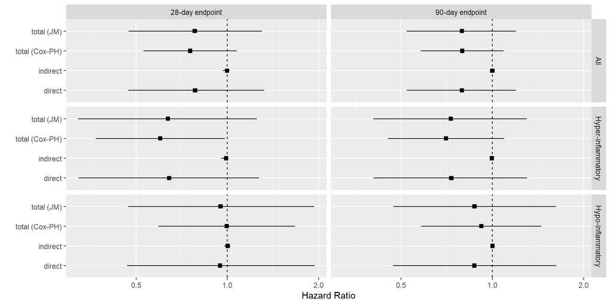

```r
res %>%
  ggplot(aes(y = effect))+
  theme_grey()+
  geom_point(aes(x=exp(est)), shape=15, size=2) +
  geom_linerange(aes(xmin=exp(CI_lower), xmax=exp(CI_upper))) +
   geom_vline(xintercept = 1, linetype="dashed") +
  labs(x="Hazard Ratio", y= "")+
  scale_x_continuous(trans = "log2")+
  facet_grid(class~endpoint)
```

#### 4.2. Association parameter

Hazard ratio estimate and 95% CI for the association parameter $\alpha$ for a one unit increase (at any time point) of IL-6 and the hazard of death.

```r
# save association estimates

alpha_28 <- get_alpha(jointfit.harp2_28, "28-day endpoint") %>% cbind(class = "All")
alpha_28_y <- get_alpha(jointfit.harp2_hyper_28, "28-day endpoint") %>% cbind(class = "Hyper-inflammatory")
alpha_28_o <- get_alpha(jointfit.harp2_hypo_28, "28-day endpoint") %>% cbind(class = "Hypo-inflammatory")

alpha_90 <- get_alpha(jointfit.harp2_90, "90-day endpoint")  %>% cbind(class = "All")
alpha_90_y <- get_alpha(jointfit.harp2_hyper_90, "90-day endpoint") %>% cbind(class = "Hyper-inflammatory")
alpha_90_o <- get_alpha(jointfit.harp2_hypo_90, "90-day endpoint") %>% cbind(class = "Hypo-inflammatory")

alpha_est <- rbind(alpha_28, alpha_28_o, alpha_28_y, alpha_90, alpha_90_o, alpha_90_y)

saveRDS(alpha_est, "harp2_alpha_est.rds")
```

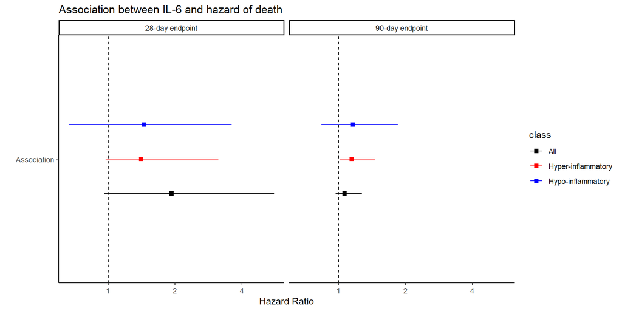

```r
alpha_est %>%
  ggplot(aes(y = model, fill = class, col = class)) +
      scale_color_manual(values=c("black","red", "blue"))+
  theme_classic()+
  geom_point(aes(x=exp(est)), shape=15, size=2, position=position_dodge(width = 0.5)) +
  geom_linerange(aes(xmin=exp(CI_lower), xmax=exp(CI_upper)), position=position_dodge(width = 0.5)) +
   geom_vline(xintercept = 1, linetype="dashed") +
  labs(x="Hazard Ratio", y= "")+
  scale_x_continuous(trans ="log2")+
  ggtitle("Association between IL-6 and hazard of death")+
  facet_grid(~endpoint)
```

### 5. Model checks

#### 5.1. Longitudinal submodel

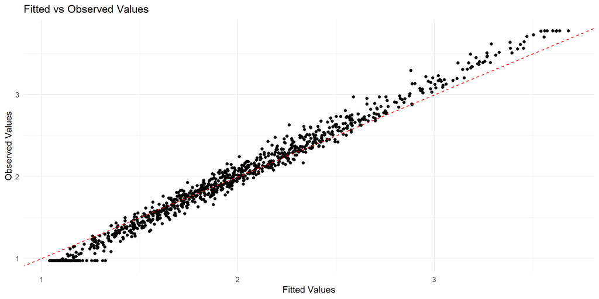

```r
# get fitted values
fitted_values<- fitted(lmefit.harp2)
harp2_long <- harp2_long %>%  drop_na(conc_log10)

# plot observed vs fitted values
ggplot(data = harp2_long, aes(x = fitted_values, y = conc_log10)) +
  geom_point() +
  geom_abline(slope = 1, intercept = 0, linetype = "dashed", color = "red") +  # Line of perfect fit
  labs(x = "Fitted Values", y = "Observed Values") +
  ggtitle("Fitted vs Observed Values") +
  theme_minimal()
```

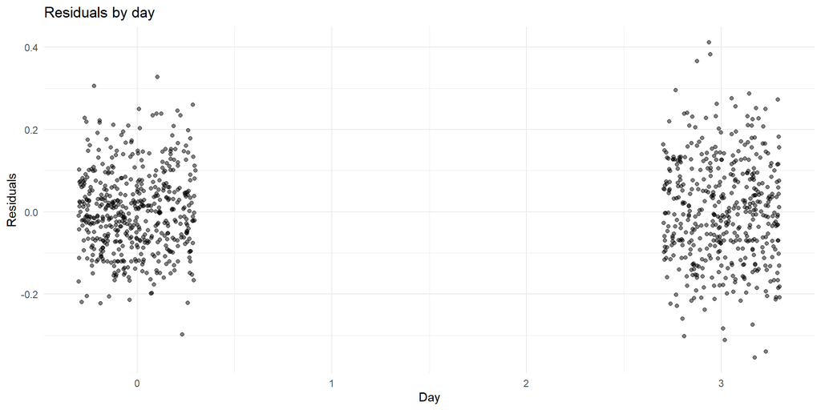

```r
# get residuals
residuals_values <- resid(lmefit.harp2)


# plot residuals vs time
ggplot(harp2_long, aes(x = day, y = residuals_values)) +
  geom_jitter(width = 0.3, alpha = 0.5) +
  labs(x = "Day", y = "Residuals") +
  ggtitle("Residuals by day") +
  theme_minimal()
```

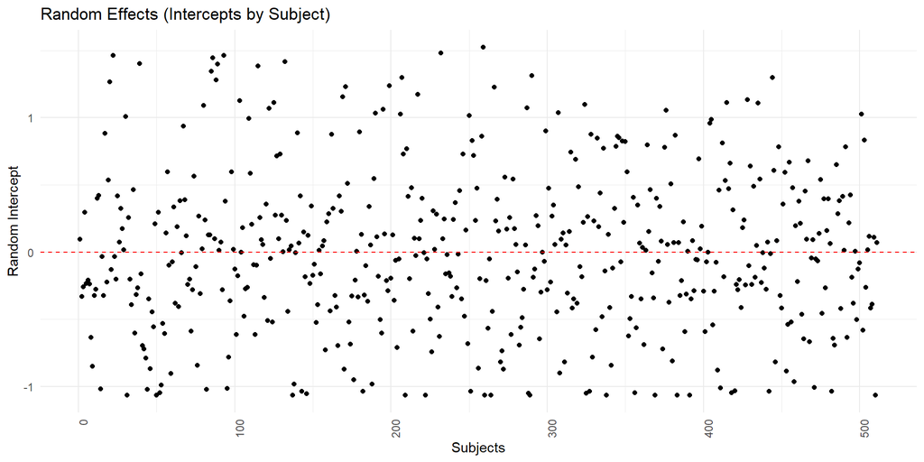

```r
# get random effects
random_effects <- ranef(lmefit.harp2)

#plot random effects
ggplot(random_effects, aes(x = c(1:(nrow(harp2_surv)-1)), y = `(Intercept)`)) +
  geom_point() +
  geom_hline(yintercept = 0, linetype = "dashed", color = "red") +
  labs(x = "Subjects", y = "Random Intercept") +
  ggtitle("Random Effects (Intercepts by Subject)") +
  theme_minimal() +
  theme(axis.text.x = element_text(angle = 90, hjust = 1))
```

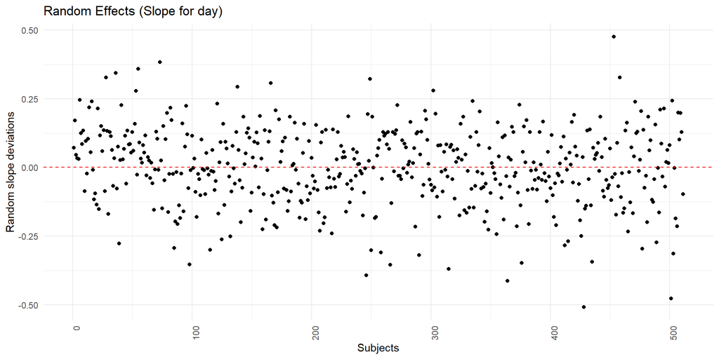

```r
#plot random effects
ggplot(random_effects, aes(x = c(1:(nrow(harp2_surv)-1)), y = `day`)) +
  geom_point() +
  geom_hline(yintercept = 0, linetype = "dashed", color = "red") +
  labs(x = "Subjects", y = "Random slope deviations") +
  ggtitle("Random Effects (Slope for day)") +
  theme_minimal() +
  theme(axis.text.x = element_text(angle = 90, hjust = 1))
```

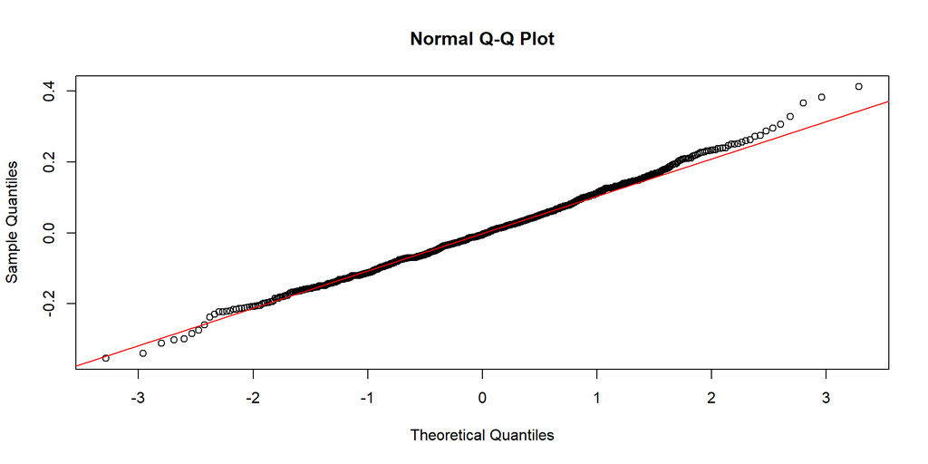

```r
# qq plot for residuals
qqnorm(resid(lmefit.harp2))

qqline(resid(lmefit.harp2), col = "red")
```

#### 5.2 Survival submodel 28-day endpoint

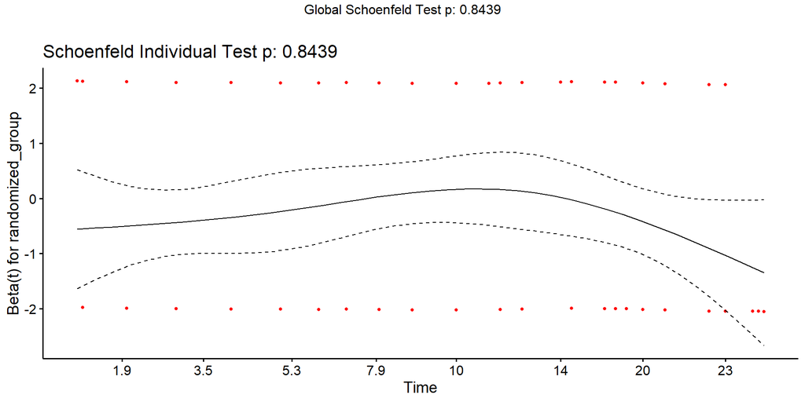

```r
test.ph <- cox.zph(coxfit.harp2_28)
survminer::ggcoxzph(test.ph)
```

#### 5.3 Survival submodel 28-day endpoint hyper

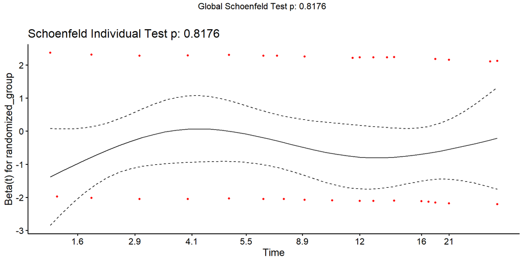

```r
test.ph <- cox.zph(coxfit.harp2_hyper_28)
survminer::ggcoxzph(test.ph)
```

#### 5.4 Survival submodel 28-day endpoint hypo

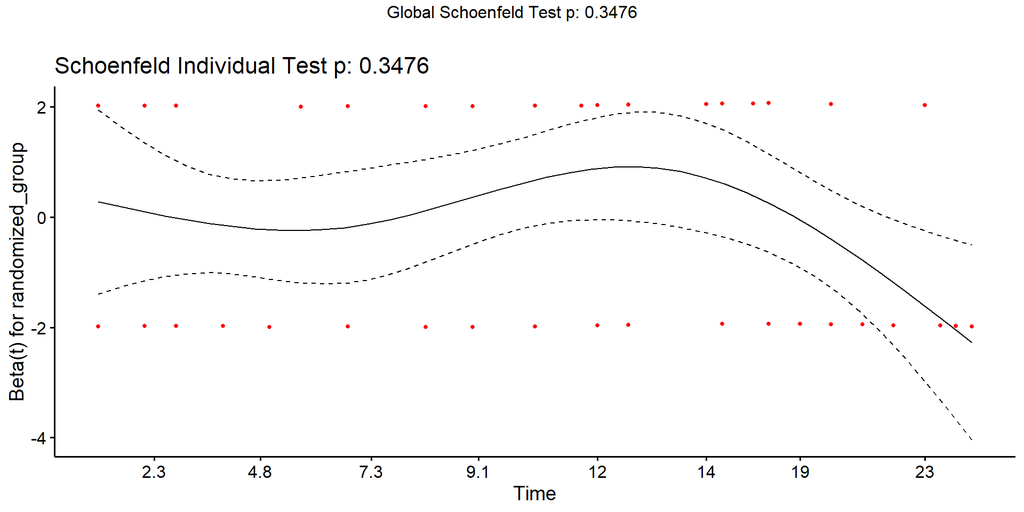

```r
test.ph <- cox.zph(coxfit.harp2_hypo_28)
survminer::ggcoxzph(test.ph)
```

#### 5.5. Joint model traceplots 28-day endpoint

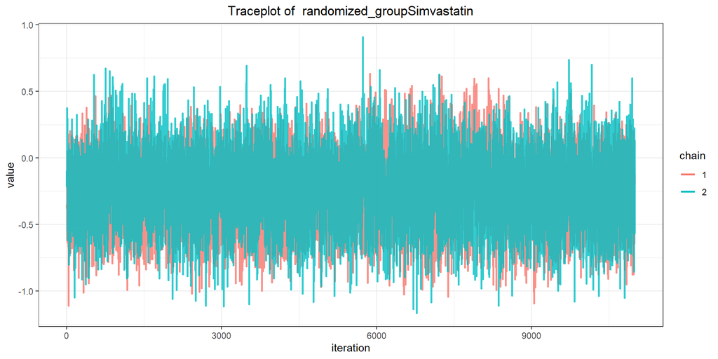

```r
ggtraceplot(jointfit.harp2_28, "gammas")
```

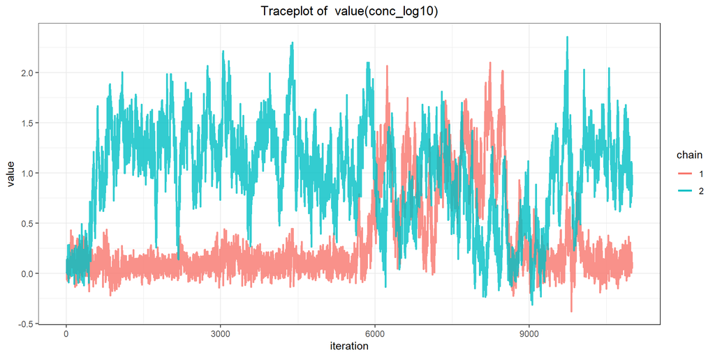

```r
ggtraceplot(jointfit.harp2_28, "alphas")
```

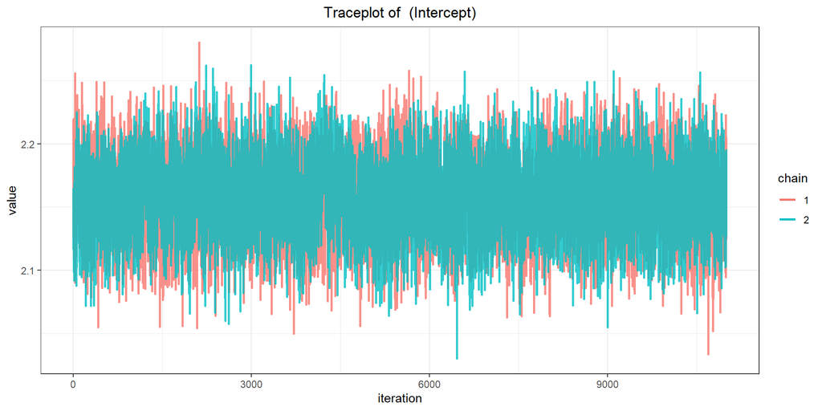

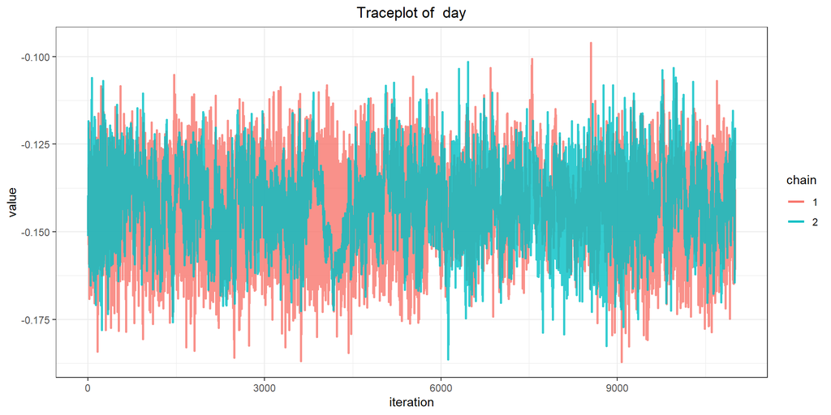

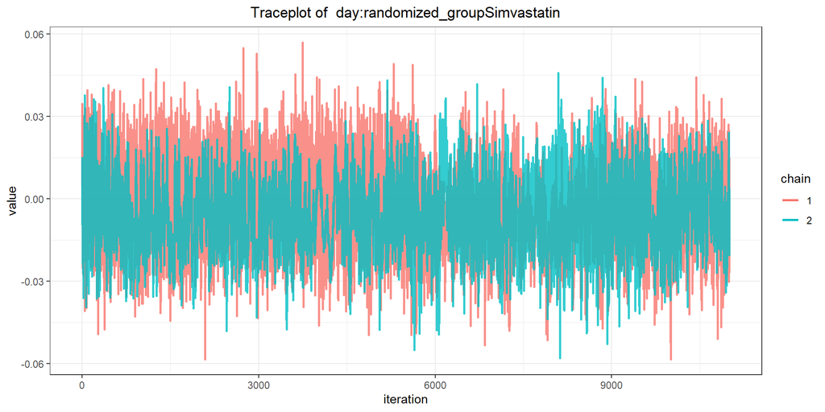

```r
ggtraceplot(jointfit.harp2_28, "betas")
```

#### 5.6. Joint model traceplots 28-day endpoint hyper

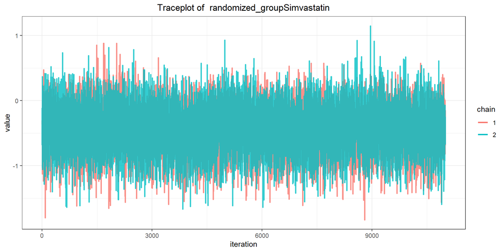

```r
ggtraceplot(jointfit.harp2_hyper_28, "gammas")
```

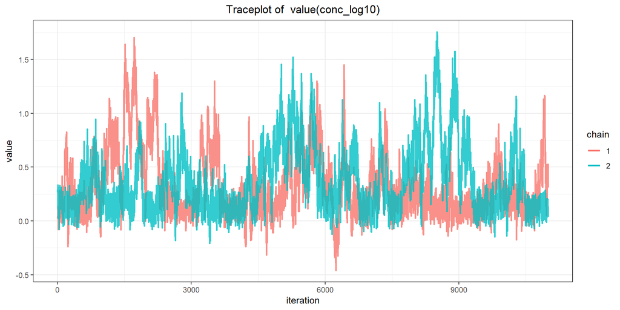

```r
ggtraceplot(jointfit.harp2_hyper_28, "alphas")
```

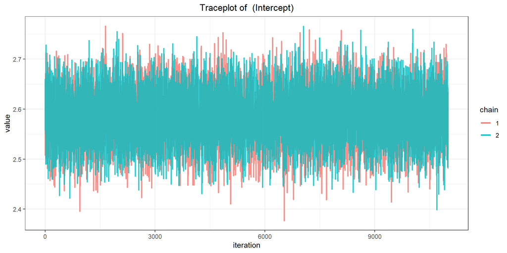

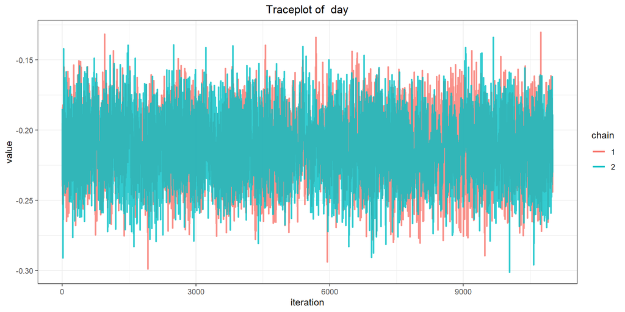

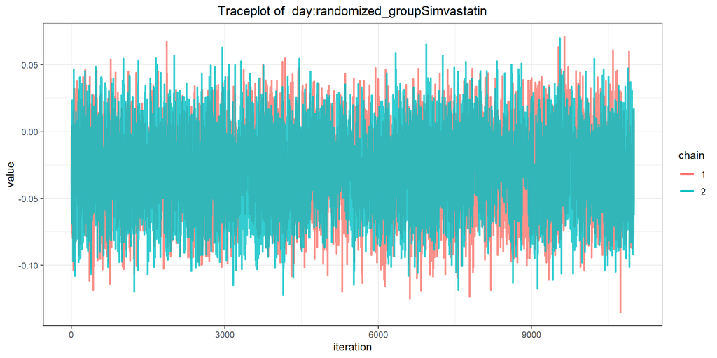

```r
ggtraceplot(jointfit.harp2_hyper_28, "betas")
```